# R: Préparation

02 mai 2018

## R

## Espace de travail

Dossier personnel, appelé **~** par RStudio :

```r
Sys.getenv("R_USER")
```

```
## [1] "C:/Users/Eric.Marcon/Documents"
```

- Mes Documents sous Windows ;
- Home sous Mac ou Linux.

Travailler dans un sous-dossier, par exemple : *Formation*.

Pas d'espace ni caractère spécial dans les noms de dossier.

## Versions de R

Trois à six versions par an. Utiliser impérativement la mineure en cours (ex.: 3.4).

R ne désinstalle pas les versions précédentes :

- Désinstaller manuellement ;
- Nettoyer le dossier des packages *~/R/win-library/version*

```r
Sys.getenv("R_LIBS_USER")
```

```
## [1] "C:/Users/Eric.Marcon/Documents/R/win-library/3.4"
```

## Librairies système et utilisateur

Stockage des packages dans la librairie système si R peut y écrire.

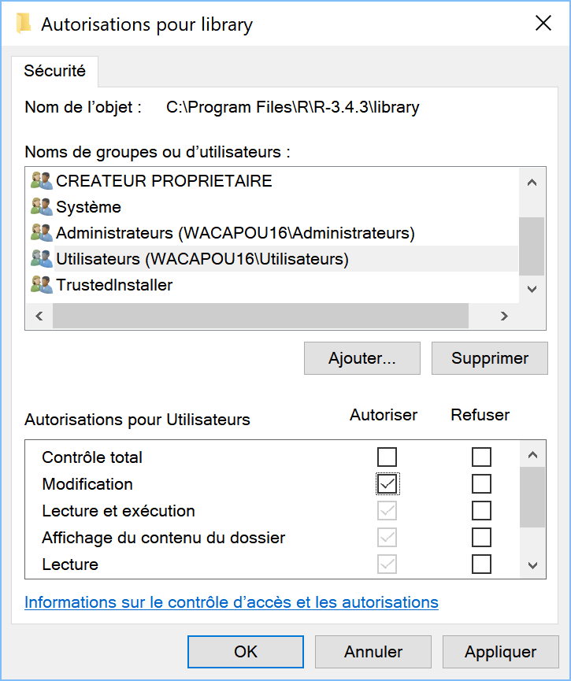

## RStudio

## Environnement de travail

Incontournable.

Intègre la majorité des outils utiles.

Version > 1 indispensable.

[RStudio Server](https://www.ecofog.gf/RStudio1/) est strictement équivalent.

## Projet

Organiser le travail en projets :

- un dossier dans ~ (ou un sous-dossier de ~) ;
- un fichier .Rproj dans le dossier.

Création par le menu *New Project*.

Pas de caractères spéciaux, pas d'espace dans le nom.

## Environnement de travail

La fenêtre *Environnement* liste les variables et fonctions.

- Sauvegarde dans un fichier RData / Ouverture d'un RData ;
- Sauvegarde automatique en fin de session.

La fenêtre *History* liste l'historique des commandes:

- Sauvegarde, idem ;
- Envoi à la console ou au fichier source.

## Packages

Utiliser un fichier *Packages.R*.

```r
# Install necessary packages only
InstallPackages <- function(Packages) {
    sapply(Packages, function(Package) if (!Package %in%
        installed.packages()[, 1])
        install.packages(Package))
}
# Markdown
InstallPackages(c("base64enc", "knitr", "rmarkdown",
    "bookdown"))
# Other packages
InstallPackages(c("RODBC", "devtools"))
# EcoFoG
devtools::install_github("EcoFoG/EcoFoG")
```

## Package EcoFoG

[Sur GitHub](https://ecofog.github.io/EcoFoG/Introduction.html).

Contient des modèles d'article, de présentation, d'ouvrage.

Contient du code à usage interne :

- Accès à la base Guyafor ;
- Outil pour la création de cartes de Paracou.

En développement…

## Logiciels

## Architecture

R utilise des packages et appelle des programmes externes pour la création de documents et de packages.

Liste avec liens maintenue dans la [vignette du package EcoFoG](https://ecofog.github.io/EcoFoG/Introduction.html#environnement-logiciel).

## Packages R

- devtools : utilitaires pour le développement ;
- knitr, rmarkdown, bookdown: rédaction avec RMarkdown.

Utiliser *Packages.R* pour une réinstallation rapide.

## LaTeX

Production de fichiers PDF :

- Présentations Beamer ;
- Articles et ouvrages PDF.

Installer *MikTex* sous Windows, *MacTex* sous Mac, *TexLive* sous Linux.

Compléter par *TeXstudio* pour débugger les compilations difficiles et *Jabref* pour gérer les fichiers bib.

## Bibliographie

Utiliser un gestionnaire bibliographique capable de produire un fichier *bib* : *Mendeley* ou *Zotero.*

*Jabref* permet de gérer totalement sa bibliographie au format *BibTeX*.

## Développement

Sous Windows, compléter R par Rtools : outils pour R.

Installations souhaitables :

- ImageMagik : traitement des images ;
- qpdf : vérification de la compression des fichiers PDF ;
- Ghostscript : traitement des fichiers PDF ;
- perl : moteur de pdfcrop, pour le rognage automatique des images.

## Git

*Git* est un outil de gestion de sources.

Le moteur de Git doit être installé.

RStudio intègre une interface pour Git.

Ouvrir un compte sur [GitHub](https://github.com/) pour collaborer.